# QTPME Follow Up and Interpretations

2026-07-01

```r
knitr::opts_chunk$set(echo = FALSE)
knitr::opts_chunk$set(message = FALSE)
knitr::opts_chunk$set(comment = NULL)
knitr::opts_chunk$set(warning = FALSE)
```

### Omnibus Tests From Each of the Best Fitting Models

Fortunately, since each of the best fitting models is the three-way interaction one, we can display all of this information in one large table!

This is the output of using the anova() function with the type argument = ‘marginal’, which basically shows us the omnibust test using type III sums of squares. Basically, it is testing, does this term explain additional variation in the outcome after controlling for the effects of the other terms in the model. It is nice because this approach is not influenced by term order in the model.

**Delta**: From this model we see that there is a significant intercept, slope parameter and join point- so that is a good indicator that it is capturing a decrease in power with age and that it eventually plateaus- as we would expect.

- Sex is not significant, indicating that between males and females, their EEG log power is similar between them at age 15.
- Main effect of region is significant, but we do not care that much since it is qualified by a significant interaction term.
- region x spell group is significant- this assesses that there is a group difference between spelling group in at least one of the five regions.
- region x hemisphere is also significant, but for our purposes we do not care.
- No significant three-way interaction.

**Theta**: We do not have a significant intercept, slope, nor join point. This is interesting because this potentially telling us that for the frequency band, power is not decreasing with age as we would have expected.

- There is a main effect of region and a significant interaction between region and hemisphere- but we do not really care that much for this.
- Interestingly, there is a significant region x spell group interaction, so it looks like we can follow that up as well.

**Alpha1**: Similar to theta, there is no significant slope nor join point, which tells us that power is not decreasing with age (significantly) as we would have expected.

- There is a main effect of region but it is qualified by both its two and three-way interaction.
- This is very interesting, the three-way interaction may indicate that between good and poor spellers, there may be some group differences dependent on topography and region combinations.

Omnibus Test for the 3 Frequency Band Models

| . | Delta numDF | Delta denDF | Delta F.value | Delta p.value | Theta numDF | Theta denDF | Theta F.value | Theta p.value | Alpha1 numDF | Alpha1 denDF | Alpha1 F.value | Alpha1 p.value |
| --- | --- | --- | --- | --- | --- | --- | --- | --- | --- | --- | --- | --- |
| **Intercept Parameter (a)** |  |  |  |  |  |  |  |  |  |  |  |  |
| Intercept | 1 | 2709 | 96.571 | <0.001*** | 1 | 2709 | 0.922 | 0.337 | 1 | 2709 | 14.752 | <0.001*** |
| Sex | 1 | 296 | 0.119 | 0.731 | 1 | 296 | 0.033 | 0.856 | 1 | 296 | 0.263 | 0.608 |
| Hemisphere | 1 | 2709 | 0.299 | 0.584 | 1 | 2709 | 0.042 | 0.838 | 1 | 2709 | 3.410 | 0.065 |
| Region | 4 | 2709 | 346.274 | <0.001*** | 4 | 2709 | 320.429 | <0.001*** | 4 | 2709 | 763.061 | <0.001*** |
| Spell Group | 1 | 296 | 0.012 | 0.915 | 1 | 296 | 0.043 | 0.836 | 1 | 296 | 0.197 | 0.657 |
| Region x Spell Group | 4 | 2709 | 3.690 | 0.005** | 4 | 2709 | 2.738 | 0.027* | 4 | 2709 | 2.010 | 0.09 |
| Hemisphere x Region | 4 | 2709 | 7.798 | <0.001*** | 4 | 2709 | 4.794 | <0.001*** | 4 | 2709 | 10.580 | <0.001*** |
| Hemisphere x Spell Group | 1 | 2709 | 1.089 | 0.297 | 1 | 2709 | 1.214 | 0.271 | 1 | 2709 | 2.131 | 0.144 |
| Hemisphere x Region x Spell Group | 4 | 2709 | 1.635 | 0.163 | 4 | 2709 | 1.878 | 0.111 | 4 | 2709 | 2.588 | 0.035* |
| **Instantaneous Slope Parameter (b)** |  |  |  |  |  |  |  |  |  |  |  |  |
| Intercept | 1 | 296 | 12.530 | <0.001*** | 1 | 296 | 3.019 | 0.083 | 1 | 296 | 1.406 | 0.237 |
| Spell Group | 1 | 296 | 0.304 | 0.582 | 1 | 296 | 0.221 | 0.639 | 1 | 296 | 0.028 | 0.867 |
| **Join Point Parameter Parameter (xs)** |  |  |  |  |  |  |  |  |  |  |  |  |
| Intercept | 1 | 296 | 6.679 | 0.01* | 1 | 296 | 0.485 | 0.487 | 1 | 296 | 0.294 | 0.588 |
| Spell Group | 1 | 296 | 0.166 | 0.684 | 1 | 296 | 0.061 | 0.804 | 1 | 296 | 0.158 | 0.692 |

## Using the multcomp Package to Adjusted for Multiple Comparison

### Part 1: Delta

Essentially, we will be using the glht() function from the **multcomp** package. This function requires at least two inputs: the model we want to interpret and the **K** matrix. Essentially, we need to specify what post-hoc tests we want to do and in addition to that, control for multiple comparisons. Why do this? Because this approach gives the exact comparisons we want based on our specific hypotheses of interest, and can **provide us the p-values** that are directly associated with this specific effect, so overall this is a very powerful although redious approach to statistical analysis. This approach is calle **Post-Hoc hypothesis testing via general linear hypotheses** or more casually, **testing custom linear contrasts**.

The combination of the glht() function with summary() or confint() allow us to do this. Literally the hardest part is doing a good job specifying the **K** matrix.

From our Omnibus results, we are most interested in just following up the Region by Spell Group interaction. Specifically, what we want to do is test for group differences for each of the 5 levels in region. Since hemisphere was not significant at all, we can assume that power between good and poor spellers will be similar between left and right hemispheres, so we can just ignore that. In other words, the effects we are about to calculate for our K matrix are technically specific to the left hemisphere (reference), but as mentioned, since hemisphere is not significant nor was there a significant three way interaction with hemisphere, we can assume the upcoming effects apply equally to the left and right hemisphere. Moreover, spelling group differences are likely to be present in at least one of these regions: frontal, central, temporal, parietal, or occipital.

In addition to the 5 region tests we will be doing, we also need to test for the effect of spelling group for the slope and for the join point, plus also just estimating that slope and join point in general (not just the effect). We will need do this all in one matrix so then we can adjust the p-values to control for simultaneous testing. Thus the **k matrix will have 9 rows** just for this and have as many columns as there are terms in the model.

```r
# 1. Initialize the K matrix (9 hypotheses x 24 parameters)
K_delta <- matrix(0, nrow = 9, ncol = length(coef(delta_mod)))
colnames(K_delta) <- names(fixef(delta_mod))

# Define row names to match our hypotheses
rownames(K_delta) <- c(
  "a_Diff_Frontal",
  "a_Diff_Central",
  "a_Diff_Temporal",
  "a_Diff_Occipital",
  "a_Diff_Parietal",
  "Base_Slope_b",
  "b_Diff_Slope",
  "Base_Plateau_xs",
  "xs_Diff_Plateau"
)
```

**Creating the K matrix**:

Before we can begin, we need to understand what our beta coefficients represent- specifically for ‘parameter a’. As we can see below there are 21 of them.

```
 [1] "a.(Intercept)"
 [2] "a.SexM"
 [3] "a.hemisphereright"
 [4] "a.regionfrontal"
 [5] "a.regionoccipital"
 [6] "a.regionparietal"
 [7] "a.regiontemporal"
 [8] "a.Spell_grouplow"
 [9] "a.regionfrontal:Spell_grouplow"
[10] "a.regionoccipital:Spell_grouplow"
[11] "a.regionparietal:Spell_grouplow"
[12] "a.regiontemporal:Spell_grouplow"
[13] "a.hemisphereright:regionfrontal"
[14] "a.hemisphereright:regionoccipital"
[15] "a.hemisphereright:regionparietal"
[16] "a.hemisphereright:regiontemporal"
[17] "a.hemisphereright:Spell_grouplow"
[18] "a.hemisphereright:regionfrontal:Spell_grouplow"
[19] "a.hemisphereright:regionoccipital:Spell_grouplow"
[20] "a.hemisphereright:regionparietal:Spell_grouplow"
[21] "a.hemisphereright:regiontemporal:Spell_grouplow"
```

We, however, do not care for all of these **beta coefficients**, there are too many. But before we start removing them, let’s review what they mean. They are essentially add-ons to the **intercept beta coefficient**, which in this model represents the expected log absolute delta power for a female, who is a good speller, for their central region, in the **left hemisphere**. That is a reference comprised of four factors. Additionally, from these add-ons, there is only one main effect and that is sex, every other beta is not a main effect, for they are partitioned means due to the several interaction terms that involve the factors: spelling, region, and hemisphere.

Anyway, there are rules to how these add-ons work/are interpreted. For example, if I wanted to know more about good spellers (our reference), and how EEG power changes for them between hemispheres or across regions, then I would be interested in summing the add-ons ‘a.hemisphereright’ or ‘a.regiontemporal’ to the intercept (good spellers), or interpreting these betas as the effects of hemisphere and region for this spelling group. If I was interested only in **poor spellers**, then the rules change. I would essentially need to generate a **new intercept**, one for poor spellers, which I can do by adding the effect of poor spellers to our general intercept (a.(Intercept) + a.Spell_grouplow). With this, I can now use any interaction term that has ‘:Spell_grouplow’ and use that as an effect for poor spellers. For example, if I wanted to know the difference between poor spellers between central and frontal regions, then it would literally be ‘a.regionfrontal:Spell_grouplow’, but notice how this term as is tells me nothing compared to good spellers. Similar logic applies to the additional two-way interaction terms, you must basically change your reference to make sense of their effects.

Where do all these betas come from? Well, there is a total of 1 reference + 1 spelling effect + 1 sex effect + 4 region effects + 1 hemisphere effect + 1 x 4 (spelling & region) + 1 x 1 (spelling & hemisphere) + 1 x 4 (hemisphere & region) + 1 x 1 x 4 (spelling, hemisphere & region) = 21 effects (inlcuding intercept). However, following that logic, the beta’s by themselves (ignoring the intercept) are literally the key for us to do the specific type of hypothesis testing we want, since they are all different combination of effects and we can basically **combine them** to get the specific effects that we want to test!

Anyway, our interest is to just have **spelling group differences** for each of the topographical regions, without a care for hemisphere. This is because there was no significant three-way interaction between spelling group, region, and hemisphere- therefore we can essentially ignore hemisphere information and just focus our spelling group comparison on the regions. Thus, we will remove all beta coefficients that have mean difference for hemisphere included. Additionally, we will also remove sex since we do not care that much for this effect, especially since the omnibus test already informed us it is not a meaningful predictor of the outcome.

```
 [1] "a.(Intercept)"                    "a.regionfrontal"
 [3] "a.regionoccipital"                "a.regionparietal"
 [5] "a.regiontemporal"                 "a.Spell_grouplow"
 [7] "a.regionfrontal:Spell_grouplow"   "a.regionoccipital:Spell_grouplow"
 [9] "a.regionparietal:Spell_grouplow"  "a.regiontemporal:Spell_grouplow"
```

From these remaining effects and the intercept, let’s quickly review what each of them mean:

- a.(Intercept): A good speller central region (also female and also left hemisphere but we can ignore this entirely).

For the **effects** that do not have an interaction, these betas are additive information directly into the reference (intercept).

- a.regionfrontal: effect of frontal region compared to reference (frontal good effect)
- a.regionoccipital: effect of occipital region compared to reference (occipital good effect)
- a.regionparietal: effect of parietal region compared to reference (parietal good effect)
- a.regiontemporal: effect of temporal region compared to reference (temporal good effect)
- a.Spell_grouplow: effect of spelling compared to reference (central poor effect)

For the **interaction effects**, they basically work by providing us the region effects, just like above, however these are **specific to poor spellers**. So to generate means if we wanted to, it would be intercept + ‘a.Spell_grouplow’ + any of the regions below with ‘Spell_grouplow’ in the name. Therefore, as they are now, they represent only the region effect for a poor speller, which is not that informative.

- a.regionfrontal:Spell_grouplow: effect of frontal region and spelling to **new reference** (frontal poor vs central poor)
- a.regionoccipital:Spell_grouplow: effect of occipital region and spelling to new reference (occipital poor vs central poor)
- a.regionparietal:Spell_grouplow: effect of parietal region and spelling compared to new reference (parietal poor vs central poor)
- a.regiontemporal:Spell_grouplow: effect of temporal region and spelling compared to new reference (temporal poor vs central poor)

Let’s begin with the easiest effect. To test good vs poor spellers for the central region, we simply just estimate the beta for low spelling group (‘a.Spell_grouplow’), as that is the mean difference for the central region between spellers.

```r
# Creating the reference level first
K_delta["a_Diff_Central",   "a.Spell_grouplow"] <- 1 # Dummy coded reference
```

For the remaining regions, we need to know the effect of being a poor speller is for the **same region**. The betas above are not showing this. In previous examples, we mentioned taking the intercept and adding ‘a.Spell_grouplow’ to get the effect of poor spellers, but what if instead we do not do this? What if we sum the effect of **poor spellers** to that of an interaction of **poor spellers with frontal**, then that essentially will become the **effect of poor spelling in the frontal region**, since summing all of these three terms (intercept, poor spelling, poor spelling frontal) will result in the poor spelling frontal mean! So with that knowledge, this is how we specify our group differences for the remaining four regions!

Lastly, we also estimate the slope and the join point, along with the spelling effects for those parameters.

```r
# We sum the baseline group effect and the specific regional interaction term.
K_delta["a_Diff_Frontal",   c("a.Spell_grouplow", "a.regionfrontal:Spell_grouplow")] <- 1
K_delta["a_Diff_Temporal",  c("a.Spell_grouplow", "a.regiontemporal:Spell_grouplow")] <- 1
K_delta["a_Diff_Occipital", c("a.Spell_grouplow", "a.regionoccipital:Spell_grouplow")] <- 1
K_delta["a_Diff_Parietal",  c("a.Spell_grouplow", "a.regionparietal:Spell_grouplow")] <- 1

K_delta["Base_Slope_b",   "b.(Intercept)"] <- 1
K_delta["b_Diff_Slope",    "b.Spell_grouplow"] <- 1

K_delta["Base_Plateau_xs", "xs.(Intercept)"] <- 1
K_delta["xs_Diff_Plateau", "xs.Spell_grouplow"] <- 1
```

Below we can visualize the K matrix in two different ways. The first is using the imagemat() function, which produces a plot of shaded squares that represent what betas we want to estimate/combine (the combination is by row). Then we have the table itself showing exactly what those shaded squares represent/what is getting combined.

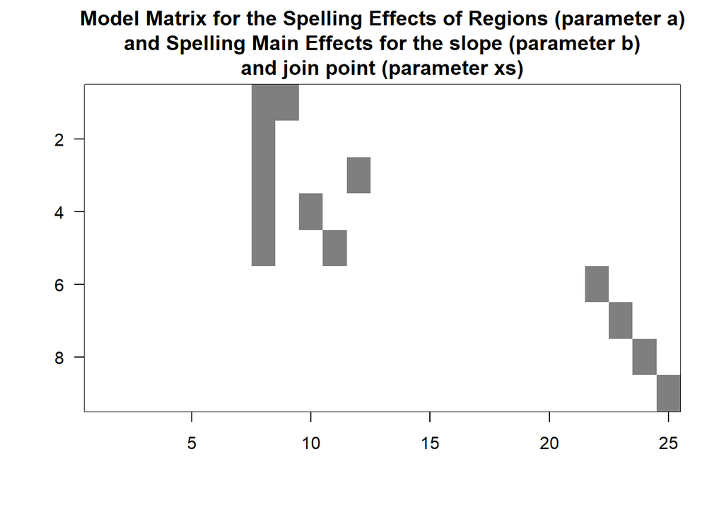

K matrix (ignoring columns with all zeroes)

|  | a.Spell_low | a.frontal:Spell_low | a.occipital:Spell_low | a.parietal:Spell_low | a.temporal:Spell_low | b.(Intercept) | b.Spell_low | xs.(Intercept) | xs.Spell_low |
| --- | --- | --- | --- | --- | --- | --- | --- | --- | --- |
| a_Diff_Frontal | 1 | 1 | 0 | 0 | 0 | 0 | 0 | 0 | 0 |
| a_Diff_Central | 1 | 0 | 0 | 0 | 0 | 0 | 0 | 0 | 0 |
| a_Diff_Temporal | 1 | 0 | 0 | 0 | 1 | 0 | 0 | 0 | 0 |
| a_Diff_Occipital | 1 | 0 | 1 | 0 | 0 | 0 | 0 | 0 | 0 |
| a_Diff_Parietal | 1 | 0 | 0 | 1 | 0 | 0 | 0 | 0 | 0 |
| Base_Slope_b | 0 | 0 | 0 | 0 | 0 | 1 | 0 | 0 | 0 |
| b_Diff_Slope | 0 | 0 | 0 | 0 | 0 | 0 | 1 | 0 | 0 |
| Base_Plateau_xs | 0 | 0 | 0 | 0 | 0 | 0 | 0 | 1 | 0 |
| xs_Diff_Plateau | 0 | 0 | 0 | 0 | 0 | 0 | 0 | 0 | 1 |

Now we will run the glht() function using the completed K matrix from above. From that, we could use the summary() function on it to get our estimates and their adjusted p-values. However, we decided it would be best to adjust the p-values using the Benjamini-Hochberg (BH) approach, which adjust p-values to control the False Discovery Rate (FDR), so it is more powerful than other test that tries to control the Family Wise Error Rate (FWER). We do however use FWER when it comes to generating the 95% confidence intervals, so the adjusted p-values and the 95% CIs are not goint to produce the exact same results in a sense, but that is okay.

```r
# Run the glht() function on the model with the K matrix
simple_glht <- glht(delta_mod, linfct = K_delta)

# Extract simultaneous confidence intervals from the glht object (have been corrected for)
ci_delta <- confint(simple_glht)

# The authors suggest this for exploratory topographic research [3, 4].
raw_results <- summary(simple_glht, test = adjusted("none"))

# 6. Apply Benjamini-Hochberg (BH) adjustment (from Source 1 and 5)
# This controls the False Discovery Rate while maintaining high power [5, 6].
adj_p_bh <- p.adjust(raw_results$test$pvalues, method = "BH")

# 7. Create a summary table
final_table_delta <- data.frame(
  Hypothesis = rownames(K_delta),
  Estimate = raw_results$test$coefficients,
  StdError = raw_results$test$sigma,
  adj_lower_CI = ci_delta$confint[, "lwr"],
  adj_upper_CI = ci_delta$confint[, "upr"],
  Adjusted_P_BH = adj_p_bh,
  Raw_P = raw_results$test$pvalues
)

# Remove row names
row.names(final_table_delta) <- NULL
```

We can basically test whether or not we went about specifying the K matrix in the correct way. By using the beta estimate coefficients from fixef(delta_mod), we were able to calculate by hand what the spelling differences between groups for each region would be. I mean we should be able to do this by hand, but the glht() with the K matrix gives us the **associated p-values**, that we can’t get by hand.

**Spelling group differences**:

- central: -0.019319 (Spell_grouplow )
- frontal: -0.019319 + 0.139675 = 0.120356 (Spell_grouplow + regionfrontal:Spell_grouplow)
- occipital: -0.019319 + (-0.071468) = -0.090787 (Spell_grouplow + regionoccipital:Spell_grouplow)
- parietal: -0.019319 + 0.005794 = -0.013525 (Spell_grouplow + regionparietal:Spell_grouplow)
- temporal: -0.019319 + 0.098494 = 0.079175 (Spell_grouplow + regiontemporal:Spell_grouplow)

Beta Estimates for the Delta QTPME Model

| Hypothesis | Estimate | StdError | adj_lower_CI | adj_upper_CI | Adjusted_P_BH | Raw_P |
| --- | --- | --- | --- | --- | --- | --- |
| a_Diff_Frontal | 0.120 | 0.179 | -0.329 | 0.570 | 0.877 | 0.502 |
| a_Diff_Central | -0.019 | 0.179 | -0.469 | 0.430 | 0.940 | 0.914 |
| a_Diff_Temporal | 0.079 | 0.179 | -0.370 | 0.529 | 0.877 | 0.659 |
| a_Diff_Occipital | -0.091 | 0.179 | -0.540 | 0.359 | 0.877 | 0.612 |
| a_Diff_Parietal | -0.014 | 0.179 | -0.463 | 0.436 | 0.940 | 0.940 |
| Base_Slope_b | -0.086 | 0.024 | -0.146 | -0.025 | 0.003 | 0.000 |
| b_Diff_Slope | -0.034 | 0.062 | -0.189 | 0.121 | 0.877 | 0.580 |
| Base_Plateau_xs | 17.639 | 6.797 | 0.579 | 34.700 | 0.043 | 0.009 |
| xs_Diff_Plateau | -3.742 | 9.137 | -26.676 | 19.191 | 0.877 | 0.682 |

Overall, there is **not much evidence that good and poor spellers differ in absolute delta power**. Even though the omnibus test showed a significant Region × Spell Group interaction, none of the individual regional group differences were significant after correcting for multiple comparisons. This probably means that the group differences themselves vary across regions (for example, the frontal difference was positive whereas the occipital difference was negative), but the differences are too small and inconsistent to conclude that poor and good spellers differ in any specific region.

For development, delta power showed the expected decrease with age and appeared to plateau in early adulthood (around 33 years old), although there is a lot of uncertainty around the exact age of the plateau. More importantly, poor and good spellers did not differ in how quickly delta power changed with age or when it reached a plateau. Therefore, for the delta frequency band, there is little evidence supporting either the maturational lag hypothesis or the neurophysiological deficit hypothesis. Instead, **both groups appear to show very similar developmental trajectories**.

### Part 2: Theta

Here we are basically creating the **same K matrix** as we did above. So we will have a 9 row matrix that will report spell group differences for each of the 5 regions along with the general slope and join point and the effect of being a poor speller.

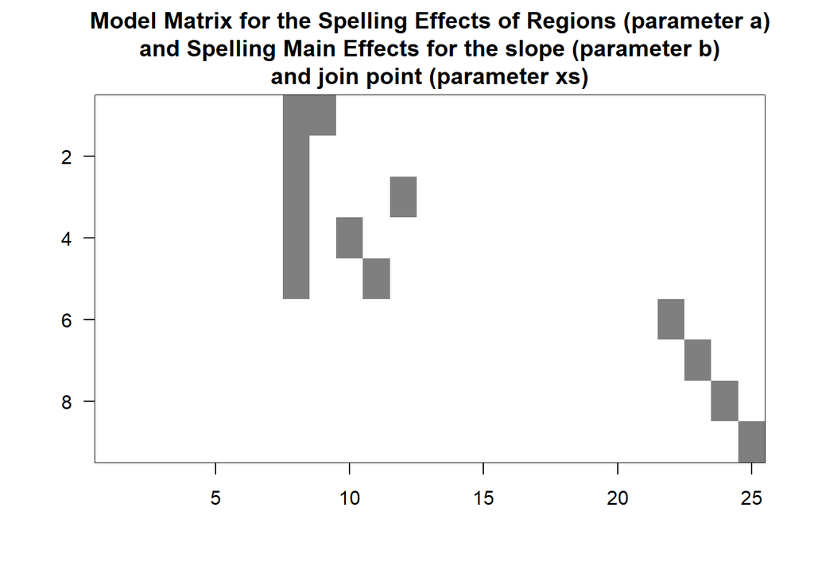

K matrix (ignoring columns with all zeroes)

|  | a.Spell_low | a.frontal:Spell_low | a.occipital:Spell_low | a.parietal:Spell_low | a.temporal:Spell_low | b.(Intercept) | b.Spell_low | xs.(Intercept) | xs.Spell_low |
| --- | --- | --- | --- | --- | --- | --- | --- | --- | --- |
| a_Diff_Frontal | 1 | 1 | 0 | 0 | 0 | 0 | 0 | 0 | 0 |
| a_Diff_Central | 1 | 0 | 0 | 0 | 0 | 0 | 0 | 0 | 0 |
| a_Diff_Temporal | 1 | 0 | 0 | 0 | 1 | 0 | 0 | 0 | 0 |
| a_Diff_Occipital | 1 | 0 | 1 | 0 | 0 | 0 | 0 | 0 | 0 |
| a_Diff_Parietal | 1 | 0 | 0 | 1 | 0 | 0 | 0 | 0 | 0 |
| Base_Slope_b | 0 | 0 | 0 | 0 | 0 | 1 | 0 | 0 | 0 |
| b_Diff_Slope | 0 | 0 | 0 | 0 | 0 | 0 | 1 | 0 | 0 |
| Base_Plateau_xs | 0 | 0 | 0 | 0 | 0 | 0 | 0 | 1 | 0 |
| xs_Diff_Plateau | 0 | 0 | 0 | 0 | 0 | 0 | 0 | 0 | 1 |

Beta Estimates for the Theta QTPME Model

| Hypothesis | Estimate | StdError | adj_lower_CI | adj_upper_CI | Adjusted_P_BH | Raw_P |
| --- | --- | --- | --- | --- | --- | --- |
| a_Diff_Frontal | 0.058 | 0.251 | -0.559 | 0.675 | 0.939 | 0.817 |
| a_Diff_Central | -0.052 | 0.251 | -0.669 | 0.565 | 0.939 | 0.835 |
| a_Diff_Temporal | 0.005 | 0.251 | -0.612 | 0.622 | 0.985 | 0.985 |
| a_Diff_Occipital | -0.123 | 0.251 | -0.740 | 0.494 | 0.939 | 0.624 |
| a_Diff_Parietal | -0.077 | 0.251 | -0.694 | 0.540 | 0.939 | 0.759 |
| Base_Slope_b | -0.062 | 0.035 | -0.149 | 0.025 | 0.729 | 0.081 |
| b_Diff_Slope | -0.040 | 0.085 | -0.247 | 0.168 | 0.939 | 0.637 |
| Base_Plateau_xs | 26.429 | 37.802 | -66.335 | 119.192 | 0.939 | 0.484 |
| xs_Diff_Plateau | -10.031 | 40.294 | -108.909 | 88.847 | 0.939 | 0.803 |

Overall, there is essentially **no evidence that good and poor spellers differ in absolute theta power**. Although the omnibus test showed a significant Region × Spell Group interaction, none of the follow-up regional contrasts were significant after correcting for multiple comparisons. Similar to the delta results, this may indicate that the size and direction of the group differences vary somewhat across regions, but there is not enough evidence to conclude that poor and good spellers differ in theta power within any specific region.

Unlike delta, there was also little evidence of age-related changes in theta power. The instantaneous slope was negative, suggesting a possible decrease in theta power with age, but the effect was not statistically significant. Likewise, there was no clear evidence that theta power reached a plateau at a particular age, as the estimated join point was extremely uncertain and had a very wide confidence interval. Finally, poor and good spellers did not differ in either their rate of developmental change or the age at which theta power plateaued. Taken together, the theta results provide little support for either the maturational lag hypothesis or the neurophysiological deficit hypothesis and instead suggest very similar developmental trajectories between groups.

### Part 3: Alpha 1

Since we have a significant three-way interaction, we will be modifying our K matrix to look a bit different. Basically, this significant interaction indicates that there are likely differences between good and poor spellers, but this varies in terms of region and hemisphere (e.g., maybe the group difference is only present for left frontal region and nowhere else, etc.). Anyway to test this, we will now need to generate a **K matrix** that looks for group differences in region (5) x hemisphere (2) level combinations, in other words, that is 10 rows we need to investigate.

In addition to that, we will also need to estimate the slope and join point by themselves, plus the effect on these parameters from being a poor spellers, for another 4 rows, making a total of 14 rows.

```r
# 1. Initialize Alpha1 K matrix (14 rows x 25 parameters)
K_alpha1 <- matrix(0, nrow = 14, ncol = 25)
colnames(K_alpha1) <- names(fixef(alpha1_mod))

# Define row names
rownames(K_alpha1) <- c(
  "a_Diff_Frontal_Left",
  "a_Diff_Central_Left",
  "a_Diff_Temporal_Left",
  "a_Diff_Occipital_Left",
  "a_Diff_Parietal_Left",
  "a_Diff_Frontal_Right",
  "a_Diff_Central_Right",
  "a_Diff_Temporal_Right",
  "a_Diff_Occipital_Right",
  "a_Diff_Parietal_Right",
  "Base_Slope_b",
  "b_Diff_Slope",
    "Base_Plateau_xs",
  "xs_Diff_Plateau"
)
```

**Creating the K matrix**:

Just like we did for the delta dataset, let’s print our beta coefficients for our ‘parameter a’.

```
 [1] "a.(Intercept)"
 [2] "a.SexM"
 [3] "a.hemisphereright"
 [4] "a.regionfrontal"
 [5] "a.regionoccipital"
 [6] "a.regionparietal"
 [7] "a.regiontemporal"
 [8] "a.Spell_grouplow"
 [9] "a.regionfrontal:Spell_grouplow"
[10] "a.regionoccipital:Spell_grouplow"
[11] "a.regionparietal:Spell_grouplow"
[12] "a.regiontemporal:Spell_grouplow"
[13] "a.hemisphereright:regionfrontal"
[14] "a.hemisphereright:regionoccipital"
[15] "a.hemisphereright:regionparietal"
[16] "a.hemisphereright:regiontemporal"
[17] "a.hemisphereright:Spell_grouplow"
[18] "a.hemisphereright:regionfrontal:Spell_grouplow"
[19] "a.hemisphereright:regionoccipital:Spell_grouplow"
[20] "a.hemisphereright:regionparietal:Spell_grouplow"
[21] "a.hemisphereright:regiontemporal:Spell_grouplow"
```

As we mentioned, there are 21 beta coefficients above, of which 20 represent effects (the intercept does not), and we need to combine them in such a way to generate 10 general linear hypothesis tests, except this time we can’t just remove all the hemisphere betas because now we need them.

So basically now we are forced to think (although AI could help us with this quiet easily wink wink). We remember that the reference EEG activity for a female (does not matter), who is a good reader (matters), for their central region (matters) in the left hemisphere (matters). So then, if I wanted to know the **effect** of being a poor speller for this same topographical region (central & left), then I would need to estimate the effect of being a poor reader (‘a.Spell_grouplow’)

```r
# Creating the reference level first (central left)
K_alpha1["a_Diff_Central_Left",   "a.Spell_grouplow"] <- 1
```

Now then, if I wanted to know the effect of being a poor speller for the central region in the **right hemisphere**, then as discussed before, all I need to do is sum up the effect of being a poor speller (‘a.Spell_grouplow’) with the effect of right hemisphere effect specifically for poor spellers (a.hemisphereright:Spell_grouplow). Why do this? Because the intercept + ‘a.Spell_grouplow’ + ‘a.hemisphereright:Spell_grouplow’ represents the expected EEG for a female who is a poor speller, for their central region, for their right hemisphere. So subtracting this mean from the intercept, gives us that right hemisphere low spelling for central region effect.

```r
# Central (but right)
K_alpha1["a_Diff_Central_Right",  c("a.Spell_grouplow",
                                    "a.hemisphereright:Spell_grouplow")] <- 1
```

We have 8 more contrasts to create for parameter a. The ones for the left hemisphere are easier to specify than that of the right so let’s do those next. We will need the ‘a.Spell_grouplow’ and combine it with effects that capture the remaining four non-central regions. Thus by looking at the list of beta coefficients, these would be:

- a.regionfrontal:Spell_grouplow
- a.regionoccipital:Spell_grouplow
- a.regionparietal:Spell_grouplow
- a.regiontemporal:Spell_grouplow

```r
### Specifying the left hemisphere contrasts

# Frontal
K_alpha1["a_Diff_Frontal_Left",   c("a.Spell_grouplow",
                                    "a.regionfrontal:Spell_grouplow")] <- 1

# Temporal
K_alpha1["a_Diff_Temporal_Left",  c("a.Spell_grouplow",
                                    "a.regiontemporal:Spell_grouplow")] <- 1

# Occipital
K_alpha1["a_Diff_Occipital_Left",  c("a.Spell_grouplow",
                                     "a.regionoccipital:Spell_grouplow")] <- 1

# Parietal
K_alpha1["a_Diff_Parietal_Left",  c("a.Spell_grouplow",
                                    "a.regionparietal:Spell_grouplow")] <- 1
```

- “a.hemisphereright:regionfrontal:Spell_grouplow”
- “a.hemisphereright:regionoccipital:Spell_grouplow”
- “a.hemisphereright:regionparietal:Spell_grouplow”
- “a.hemisphereright:regiontemporal:Spell_grouplow”

Then after that we can specify the slope and joint point along with the effect of poor spelling for both.

```r
### Specifying the right hemisphere contrasts

K_alpha1["a_Diff_Frontal_Right",  c("a.Spell_grouplow",
                                    "a.hemisphereright:Spell_grouplow",
                                    "a.regionfrontal:Spell_grouplow",
                                    "a.hemisphereright:regionfrontal:Spell_grouplow")] <- 1

K_alpha1["a_Diff_Temporal_Right", c("a.Spell_grouplow",
                                    "a.hemisphereright:Spell_grouplow",
                                    "a.regiontemporal:Spell_grouplow",
                                    "a.hemisphereright:regiontemporal:Spell_grouplow")] <- 1

K_alpha1["a_Diff_Occipital_Right", c("a.Spell_grouplow",
                                     "a.hemisphereright:Spell_grouplow",
                                     "a.regionoccipital:Spell_grouplow",
                                     "a.hemisphereright:regionoccipital:Spell_grouplow")] <- 1

K_alpha1["a_Diff_Parietal_Right", c("a.Spell_grouplow",
                                    "a.hemisphereright:Spell_grouplow",
                                    "a.regionparietal:Spell_grouplow",
                                    "a.hemisphereright:regionparietal:Spell_grouplow")] <- 1

# 3. Map 'b' and 'xs' differences (Lag Hypothesis)
K_alpha1["b_Diff_Slope",    "b.Spell_grouplow"] <- 1
K_alpha1["xs_Diff_Plateau", "xs.Spell_grouplow"] <- 1

# 4. Map 'b' and 'xs' baselines (Biological Foundation)
K_alpha1["Base_Slope_b",   "b.(Intercept)"] <- 1
K_alpha1["Base_Plateau_xs", "xs.(Intercept)"] <- 1
```

Below we can see our K matrix visualized by the imagemat() function. Essentially, the first 5 rows of the matrix are identical to the K matrix from the delta and theta dataset. What this is showing, is that all of these contrasts have the ‘a.Spell_grouplow’ embedded within them, which looks to be column 8. In the first 5 rows, the additional squares (with the exception of row 2) are the added effects of region. In the subsequent 5 rows, it is a repeat of these effects, except now we are adding **right hemisphere** information, which is column 17. The additional squares represent right hemisphere for specific regions. Lastly, the remaining 4 rows are essentially the same as the K matrix for delta and theta, it’s the slope and joint point information.

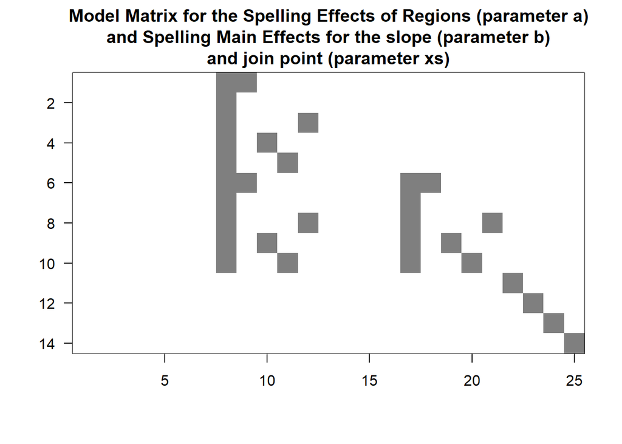

K matrix (ignoring columns with all zeroes)

|  | a.Spell_low | a.frontal:Spell_low | a.occipital:Spell_low | a.parietal:Spell_low | a.temporal:Spell_low | a.hemisphereright:Spell_low | a.hemisphereright:frontal:Spell_low | a.hemisphereright:occipital:Spell_low | a.hemisphereright:parietal:Spell_low | a.hemisphereright:temporal:Spell_low | b.(Intercept) | b.Spell_low | xs.(Intercept) | xs.Spell_low |
| --- | --- | --- | --- | --- | --- | --- | --- | --- | --- | --- | --- | --- | --- | --- |
| a_Diff_Frontal_Left | 1 | 1 | 0 | 0 | 0 | 0 | 0 | 0 | 0 | 0 | 0 | 0 | 0 | 0 |
| a_Diff_Central_Left | 1 | 0 | 0 | 0 | 0 | 0 | 0 | 0 | 0 | 0 | 0 | 0 | 0 | 0 |
| a_Diff_Temporal_Left | 1 | 0 | 0 | 0 | 1 | 0 | 0 | 0 | 0 | 0 | 0 | 0 | 0 | 0 |
| a_Diff_Occipital_Left | 1 | 0 | 1 | 0 | 0 | 0 | 0 | 0 | 0 | 0 | 0 | 0 | 0 | 0 |
| a_Diff_Parietal_Left | 1 | 0 | 0 | 1 | 0 | 0 | 0 | 0 | 0 | 0 | 0 | 0 | 0 | 0 |
| a_Diff_Frontal_Right | 1 | 1 | 0 | 0 | 0 | 1 | 1 | 0 | 0 | 0 | 0 | 0 | 0 | 0 |
| a_Diff_Central_Right | 1 | 0 | 0 | 0 | 0 | 1 | 0 | 0 | 0 | 0 | 0 | 0 | 0 | 0 |
| a_Diff_Temporal_Right | 1 | 0 | 0 | 0 | 1 | 1 | 0 | 0 | 0 | 1 | 0 | 0 | 0 | 0 |
| a_Diff_Occipital_Right | 1 | 0 | 1 | 0 | 0 | 1 | 0 | 1 | 0 | 0 | 0 | 0 | 0 | 0 |
| a_Diff_Parietal_Right | 1 | 0 | 0 | 1 | 0 | 1 | 0 | 0 | 1 | 0 | 0 | 0 | 0 | 0 |
| Base_Slope_b | 0 | 0 | 0 | 0 | 0 | 0 | 0 | 0 | 0 | 0 | 1 | 0 | 0 | 0 |
| b_Diff_Slope | 0 | 0 | 0 | 0 | 0 | 0 | 0 | 0 | 0 | 0 | 0 | 1 | 0 | 0 |
| Base_Plateau_xs | 0 | 0 | 0 | 0 | 0 | 0 | 0 | 0 | 0 | 0 | 0 | 0 | 1 | 0 |
| xs_Diff_Plateau | 0 | 0 | 0 | 0 | 0 | 0 | 0 | 0 | 0 | 0 | 0 | 0 | 0 | 1 |

Overall, there is no evidence that good and poor spellers differ in absolute alpha power. Although the omnibus test showed a significant Hemisphere × Region × Spell Group interaction, none of the follow-up group contrasts were significant after correcting for multiple comparisons. The estimated group differences were all negative, suggesting that poor spellers tended to have lower alpha power than good spellers across most regions and hemispheres, but these effects were small and highly uncertain.

There was also little evidence of developmental change in alpha power. Neither the overall slope nor the estimated plateau age was statistically significant, and there were no group differences in either parameter. Similar to the theta results, the confidence intervals around the join point were extremely wide, suggesting that the data do not provide much information about when alpha power reaches a plateau. Taken together, the alpha results provide little support for either the maturational lag hypothesis or the neurophysiological deficit hypothesis and instead suggest that good and poor spellers show broadly similar alpha power and developmental trajectories.

Beta Estimates for the Alpha1 QTPME Model

| Hypothesis | Estimate | StdError | adj_lower_CI | adj_upper_CI | Adjusted_P_BH | Raw_P |
| --- | --- | --- | --- | --- | --- | --- |
| a_Diff_Frontal_Left | -0.181 | 0.574 | -1.586 | 1.224 | 0.88 | 0.752 |
| a_Diff_Central_Left | -0.256 | 0.574 | -1.661 | 1.149 | 0.88 | 0.656 |
| a_Diff_Temporal_Left | -0.232 | 0.574 | -1.637 | 1.173 | 0.88 | 0.686 |
| a_Diff_Occipital_Left | -0.386 | 0.574 | -1.790 | 1.019 | 0.88 | 0.502 |
| a_Diff_Parietal_Left | -0.317 | 0.574 | -1.722 | 1.088 | 0.88 | 0.581 |
| a_Diff_Frontal_Right | -0.279 | 0.574 | -1.684 | 1.126 | 0.88 | 0.628 |
| a_Diff_Central_Right | -0.141 | 0.574 | -1.546 | 1.264 | 0.88 | 0.806 |
| a_Diff_Temporal_Right | -0.218 | 0.574 | -1.623 | 1.186 | 0.88 | 0.704 |
| a_Diff_Occipital_Right | -0.238 | 0.574 | -1.643 | 1.167 | 0.88 | 0.679 |
| a_Diff_Parietal_Right | -0.087 | 0.574 | -1.492 | 1.318 | 0.88 | 0.880 |
| Base_Slope_b | -0.071 | 0.060 | -0.217 | 0.075 | 0.88 | 0.234 |
| b_Diff_Slope | -0.060 | 0.360 | -0.940 | 0.819 | 0.88 | 0.867 |
| Base_Plateau_xs | 24.045 | 44.191 | -84.045 | 132.136 | 0.88 | 0.586 |
| xs_Diff_Plateau | -18.173 | 45.574 | -129.646 | 93.300 | 0.88 | 0.690 |

# Overall Conclusion From the Frequency Band Results

Overall, these analyses provide **little evidence that poor and good spellers differ in resting-state EEG absolute power** in a way that supports either the maturational lag hypothesis or the neurophysiological deficit hypothesis. Across all three frequency bands, there was** no evidence that poor spellers showed different rates** of age-related change or different plateau ages, suggesting that the **age associated changes of rsEEG power are largely similar between groups**.

There was also little evidence for persistent group differences in absolute power. Although the omnibus tests suggested that group differences may vary across scalp regions (for delta and theta) or across region and hemisphere combinations (for alpha), none of the follow-up contrasts were statistically significant after controlling for multiple comparisons. Therefore, there is insufficient evidence to conclude that poor and good spellers differ in absolute delta, theta, or alpha power within any specific region or hemisphere.

The one clear developmental finding was that absolute delta power decreased with age and appeared to plateau in early adulthood, which is consistent with the broader literature on EEG maturation. However, this developmental pattern was observed similarly in both spelling groups.

The big picture is that our data do not support the idea that poor spelling skills are associated with persistent abnormalities in resting-state absolute power, nor do they support the idea that poor spellers simply show a delayed pattern of neurophysiological maturation. Instead, adolescents and adults with poor spelling skills appear to exhibit resting-state EEG activity that is largely comparable to those of good spellers.